# DotA 2 Item Analysis

Thomas Vandrus

## Motivation

The purpose of this document is to serve as an example of basic coding, analysis, and communication skills. R is my tool of choice for deriving a ‘story’ from raw data, and the RMarkdown format allows direct translation of a script to a more readable format.

Defence of the Ancients 2 is a team-based, real-time strategy game played online, colloquially referred to as Dota ([What’s a Dota?](https://dota2.gamepedia.com/Dota_2#Basic_premise)). The strategic element requires players to manage their various finite resources to achieve the objective before the other team does. One of the more important resources is ‘gold’ which is collected and spent in various ways thoughout a match, and a primary use of gold is to buy ‘items’ that strengthen your character and team relative to the other team.

This was originally a personal project to create a data-driven guide for what items one should buy in an average game of Dota, in order to maximize one’s opportunity to win. My analysis seeks to identify items associated win-rates that deviate from the average, and determine *why* they under/over-perform using both data and contextual knowledge about the game.

## About The Data

### Background

A simple approach would be to prioritize items that provide the greatest objective advantages. More expensive items as a general rule* are better at creating an advantage; the opportunity cost is that the increased time spent collecting gold is time that the enemy team could be aggressively pursuing their objective, or actively inhibiting your ability to defend or collect gold. Thus it is possible that a less-expensive item could be more useful, due to requiring less time spent to collect gold, and granting more time spent with a usable advantage. A more refined approach to buying the best items may be to select items that provide the most benefit relative to gold required, which can be partially measured. As it turns out, the game is designed so the least expensive items tend to be the most cost-efficient,*

The constraining factor is that each player may only have up to six* usable items at a time. While more expensive items in Dota are sometimes less gold-efficient (providing 4x the benefit for 5x the cost of another), they allow a greater total advantage from other items to be accumulated as the game progresses. The purpose of the analysis is to maximize the chances of *winning*, so while cost-benefit efficiency makes a convincing case as a contributing factor, different data will be required to meet the stated goals.

[Dotabuff.com](https://www.dotabuff.com/items?date=patch_7.21) collects and summarizes data about public matches of Dota played, including data about what items are used. For each match, Dotabuff has access to what items each player had at the end of the game, and which players were on the winning team. `rvest` is a package that has the tools to scrape these tables with minimal fuss. The result is a table which indicates for each item how often the item was used, and the relative proportion of games won by the players that had that item.

**Limitations**

One of the most severe limitations of working with the given data is that it is only observational, and Dota is a complex game with many factors that could influence the observed outcomes. This also limits the confidence with which causal inferences can be made; put plainly, it is hard to tell whether an item has a high associated win rate because players that buy the item get an advantage that causes them to win, or because players that are winning for other reasons have a tendency to favour that item. With this in mind, the data will be used to direct attention toward certain outstanding items, which can then be individually considered along with context from the game to determine how best to interpret the data.

A final note about items and the data being used, is the mechanic wherein many of the more expensive items are ‘built’ from combinations of less expensive items. So a situation could arise where item A was bought in hopes of later buying item B and combining them to make item C; if the game ends and the player only has item A, there is no record that their strategy was based around aquiring/having item C, and their game outcome is associated with item A. This potential to be misleading is why most of the items highlighed by the conclusion are those that are not used as building blocks for other items (exceptions will be made explicit), so that the presence of the item is most likely to reflect the intention of the player.

* Dota is an unusually complex game, and exceptions to basic rules are not only common, but intentional features. There is a reason that not even [OpenAI](https://openai.com/blog/how-to-train-your-openai-five/) attempted a data-driven solution for item selection in their experiments.

### Setup

The cost of items is available in a user-updated [Dota wiki](https://dota2.gamepedia.com/Items) but the format is less convenient to scrape, varies more over time, and more importantly the data doesn’t quite line up with the Dotabuff data with a 1:1 mapping. For the sake of this document as a demonstration, a manually-corrected static file will be used for the price lookups.

The data pulled from Dotabuff is also unsuitable for direct use, but this can be corrected in a systematic manner. Column names are replaced with appropriate R-friendly labels, quantitative data is transformed to an R-readable format, and some incomplete/ambiguous labels are made to line up with the price data. Certain outliers are also immediately discarded, specifically those with usages so low that they may not represent a general trend for performance (this also filters out several entries that are not relevant to the game, but are captured by Dota’s API). Finally, the price data is matched to the item usage/performance data, where every entry has data for both variables. This is necessary to exclude items that appear in the game but cannot be bought with gold; they represent a different aspect of the game beyond the scope of this project.

This is also a good place to mention the list of R packages used, should a reader be interested in reproducing this exercise using parts of the presented code:

```
library(data.table) # concise data manipulation
library(rvest) # tools to scrape tables direct from webpages
library(DT) # generate interactive html tables
library(ggplot2) # advanced data visualization tool
library(ggrepel) # plotting non-overlapping text labels
library(scales) # number formatting
```

```r
item.prices <- fread(file='item-prices-7_21.txt', header=TRUE, sep='\t', stringsAsFactors=FALSE)[,c(1,2)]
head(item.prices)
```

| Item | Price |
| --- | --- |
| Animal Courier | 50 |
| Clarity | 50 |
| Town Portal Scroll | 50 |
| Enchanted Mango | 70 |
| Faerie Fire | 70 |
| Observer Ward | 75 |

```r
clean <- function(tbl, prices){
  # input: three-column data frame of item-usage data, two column data frame of item-price data
  # output: data.table containing the subset of items with price and usage data

  # standardize names to something R-friendly
  names(tbl) <- c("Item","MatchesPlayed","WinRate")
  # convert numeric data from character strings
  tbl$MatchesPlayed = as.numeric(gsub(pattern=",", replacement="", x=tbl$MatchesPlayed))
  tbl$WinRate = as.numeric(gsub(pattern="%", replacement="", x=tbl$WinRate)) / 100

  # find/fix Boots of Travel labels
  bots = grep(x=tbl$Item, pattern="Boots of Travel", value=FALSE)
  tbl$Item[bots[1]] = sub("Boots of Travel", "Boots of Travel 1",x=tbl$Item[bots[1]])
  tbl$Item[bots[2]] = sub("Boots of Travel", "Boots of Travel 2",x=tbl$Item[bots[2]])
  # ignore any instances of BoT after the first two (recipes)

  # exclude low-usage items for analysis, due to volatile win rates
  tbl = tbl[tbl$MatchesPlayed > 1000,]
  # calculate relative 'UseRate'
  tbl$UseRate = round(tbl$MatchesPlayed/sum(tbl$MatchesPlayed)*5,4)

  # inner join between usage and price tables
  return(as.data.table(merge(tbl, prices, by='Item', all=FALSE)))
}
```

## Item Analysis

The preliminary model used will try to highlight high performing items with regard to win rates, while controlling for the theoretically significant effect of item cost. Based on the expected behaviour of the data, a logistic regression with linear and quadratic price effects was deemed suitable.

This report will summarize the global item performance (across all 117 unique playable characters), and then zoom in on two cases of playable characters that represent two distinct roles in the game. Differences and similarities between those cases will be used to evaluate the approach being taken, and will hopefully lead to more insights about the data and the game than any one perspective could provide.

### Global Trends

The expectation is that when averaging the item usage of all 117 playable ‘heroes’ in the game (every match for the time-period in question), there will be significant regression to the mean. If an item is very good for one hero, yet not useful to another, those effects should roughly balance out and relative performance shouldn’t deviate too far from the mean. For an item to consistently out-perform in this scenario, that is an effect worth investigating.

#### Setup

For this first section, a few extra considerations are in order to get aquainted with the data and process.

```r
# scrape the data, and get it ready for analysis
url <- 'https://www.dotabuff.com/items?date=patch_7.21'
element <- '/html/body/div[1]/div[8]/div[3]/section/article/table'
global.tbl <- html_table(html_node(x=read_html(url), xpath=element))

# first column is useless, 4th column is questionable
head(global.tbl)
```

| Item | Item | Times Used | Use Rate | Win Rate |
| --- | --- | --- | --- | --- |
| NA | Power Treads | 194,109,072 | 30.67% | 48.30% |
| NA | Blink Dagger | 169,950,061 | 26.85% | 55.98% |
| NA | Magic Wand | 166,900,067 | 26.37% | 47.94% |
| NA | Phase Boots | 142,132,055 | 22.46% | 50.84% |
| NA | Wraith Band | 129,453,525 | 20.45% | 41.85% |
| NA | Aghanim’s Scepter | 106,431,680 | 16.82% | 60.78% |

```r
# put data in valid format, match item usage to prices
global.matched <- clean(global.tbl[,c(2,3,5)], item.prices)
head(global.matched)
```

| Item | MatchesPlayed | WinRate | UseRate | Price |
| --- | --- | --- | --- | --- |
| Abyssal Blade | 26338616 | 0.6852 | 0.0347 | 6650 |
| Aeon Disk | 7406824 | 0.5903 | 0.0098 | 3350 |
| Aether Lens | 50442651 | 0.5677 | 0.0664 | 2350 |
| Aghanim’s Scepter | 106431680 | 0.6078 | 0.1402 | 4200 |
| Animal Courier | 2015 | 0.1414 | 0.0000 | 50 |
| Arcane Boots | 100022927 | 0.4850 | 0.1318 | 1400 |

From the first plot below, note that it is far from a uniform distribution with regards to item usage; relatively few items are very popular, and the majority see relatively low use. At this point it is worth acknowledging that ‘UseRate’ appeared in the raw Dotabuff data, and was re-calculated as part of the data preparation step. Adding up the original data, it sums to precisely 600%; this would seemingly imply that on average players ended the game with exactly six items. Having played, I can say for certain that this is unlikely, as there are fairly few cases where seven items are even possible, and many more cases where a player will only have four or five inventory slots filled when a game ends. This background leads me to believe the 600% total is simply a convenient assumption imposed on the data, but it needlessly inflates the presented usage rate; my data transformation uses a more realistic assumption of five items on average (and only includes uses of relevant items), but that is still just a guess meaning that absolute usage rates are uncertain.

Price appears to drive part of this preference, with the weighted average price of an item is just over 2000 gold. This fits with the in-game experience, where the least expensive items are mostly replaced, and the most expensive items are unattainable for more players (especially those on the losing team).

The third plot supports a long-held suspicion of mine: that the most popular items are not those with an inherently higher sucess rate. Rather, I would suggest that the game is designed to be balanced out over the average of many matches, and indeed the items that see the most use are centered neatly around a 50% win rate. Following the crowd doesn’t grant a competitive advantage, so there is motivation to seek a solution that does.

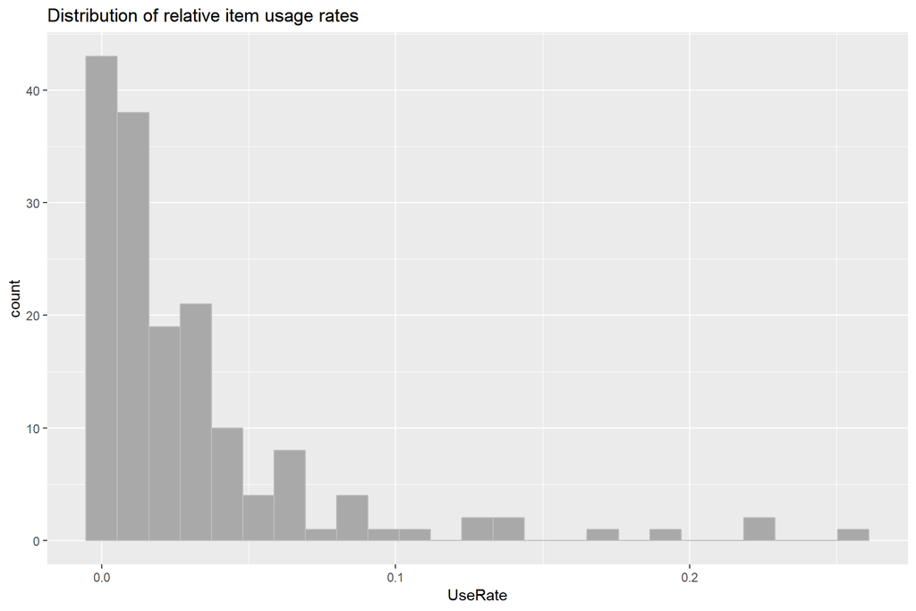

```r
gplt <- ggplot(data=global.matched)

gplt+labs(title='Distribution of relative item usage rates')+
  geom_histogram(mapping=aes(x=UseRate), bins=25 , fill='darkgrey', colour='grey')
```

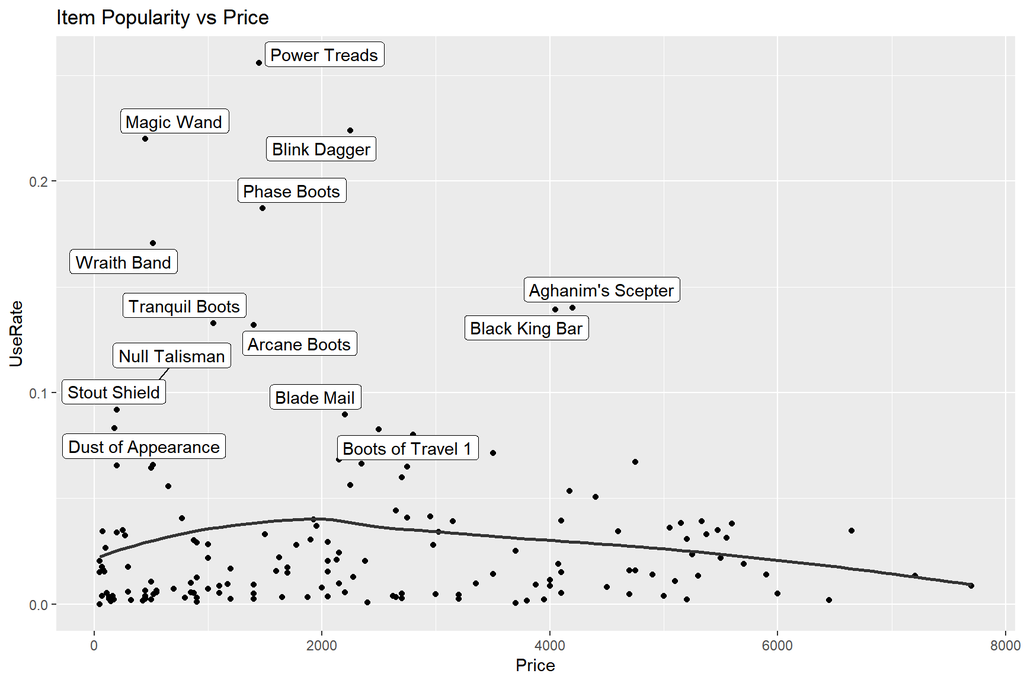

```r
gplt+labs(title='Item Popularity vs Price')+
  geom_point(mapping=aes(x=Price, y=UseRate))+
  geom_label_repel(data=global.matched[UseRate>0.08], aes(x=Price, y=UseRate, label=Item))+
  geom_smooth(mapping=aes(x=Price, y=UseRate), method='loess', se=FALSE, colour='grey20')
```

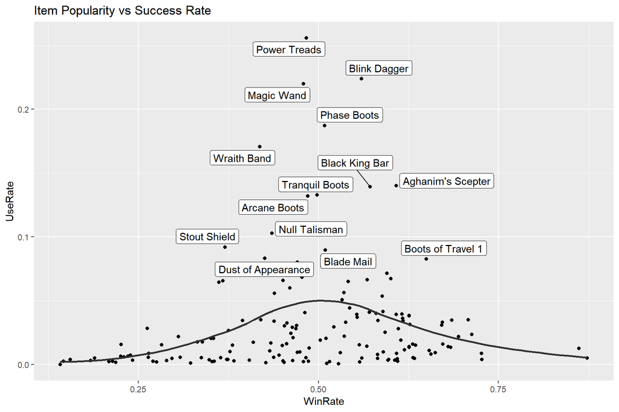

```r
gplt+labs(title='Item Popularity vs Success Rate')+
  geom_point(mapping=aes(x=WinRate, y=UseRate))+
  geom_label_repel(data=global.matched[UseRate>0.08], aes(x=WinRate, y=UseRate, label=Item))+
  geom_smooth(mapping=aes(x=WinRate, y=UseRate), method='loess', se=FALSE, colour='grey20')
```

#### Regression and Table

In order to identify items that under/over-perform, it is necessary to have some benchmark to measure them against. That is the purpose of regression modelling in this project, not to predict performance or to perfectly explain trends, just to generate a baseline level of performance that controls for the most obvious trends. While only a few notable items will be highlighted in the following plots and analysis, an interactive table (via package `DT`) of the observed and modelled data for every item is presented below.

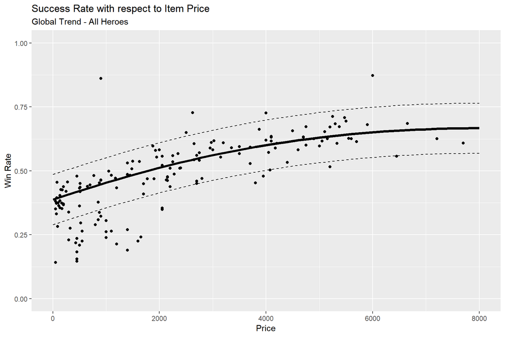

```r
# modelling and error analysis
global.glm <- glm(data=global.matched, family=binomial(link='logit'),
                  formula=WinRate~Price+I(Price^2), weights=MatchesPlayed)
global.matched$Model <- round(predict.glm(global.glm, type='response', newdata=data.frame(Price=global.matched$Price)), 4)
global.matched$Delta <- global.matched[, WinRate-Model]
global.matched$wResidual <- global.matched[,scale(Delta*MatchesPlayed)]
gplt <- ggplot(data=global.matched)

# additional information for visualization
plot.domain <- seq(0,8000, len=41)
global.model <- predict.glm(global.glm, type='response', newdata=data.frame(Price=plot.domain))
gdata <- data.frame(plot.domain, global.model)
baseline <- global.matched[,sum(MatchesPlayed*WinRate) / sum(MatchesPlayed)]
SE <- sd(global.matched$Delta)

# construct the visual
gplt+labs(title='Success Rate with respect to Item Price', subtitle='Global Trend - All Heroes')+
  xlab('Price')+ ylab('Win Rate')+
  scale_y_continuous(limits=c(0,1))+
  geom_line(data=gdata, aes(x=plot.domain, y=global.model+SE), colour='black', linetype=2)+
  geom_line(data=gdata, aes(x=plot.domain, y=global.model-SE), colour='black', linetype=2)+
  geom_line(data=gdata, aes(x=plot.domain, y=global.model), colour='black', size=1.5)+
  geom_point(mapping=aes(x=Price, y=WinRate), colour='black')
```

```r
# generate interactive table
datatable(filter='top', rownames=FALSE, escape=TRUE, options=list(order=list(5,'desc')),
          data=global.matched[,.(Item,Price,UseRate=percent(UseRate), WinRate=percent(WinRate),
                                 Model=percent(Model), Delta=percent(Delta), `Weighted Residual`=round(wResidual,2))])
```

| Item | Price | UseRate | WinRate | Model | Delta | Weighted Residual |
| --- | --- | --- | --- | --- | --- | --- |
| Abyssal Blade | 6650 | 3.5% | 68.5% | 66.0% | 2.6% | 0.41 |
| Aeon Disk | 3350 | 1.0% | 59.0% | 57.6% | 1.4% | 0.06 |
| Aether Lens | 2350 | 6.6% | 56.8% | 53.0% | 3.7% | 1.15 |
| Aghanim's Scepter | 4200 | 14.0% | 60.8% | 60.7% | 0.1% | 0.03 |
| Animal Courier | 50 | 0.0% | 14.1% | 39.1% | -25.0% | 0 |
| Arcane Boots | 1400 | 13.2% | 48.5% | 47.8% | 0.7% | 0.43 |
| Armlet of Mordiggian | 2380 | 2.0% | 51.0% | 53.2% | -2.1% | -0.2 |
| Assault Cuirass | 5250 | 2.4% | 71.3% | 63.6% | 7.7% | 0.84 |
| Band of Elvenskin | 450 | 0.2% | 14.6% | 41.8% | -27.2% | -0.31 |
| Battle Fury | 4400 | 5.1% | 53.3% | 61.4% | -8.1% | -1.89 |

[output cut: 149 more lines]

#### Visual Trend

Now that there is a model for price-adjusted average performance, it is worth noting which items represent significant departures and identifying the other possible factors at play. Ultimately the goal is not just to identify outliers, but to extract strategic advice that is justified by those peculiarities in the data.

This globally-averaged model will be compared to models fitted for two of the 117 unique heroes in Dota, specifically to see how the strategic role of a hero might influence their success rates with different items.

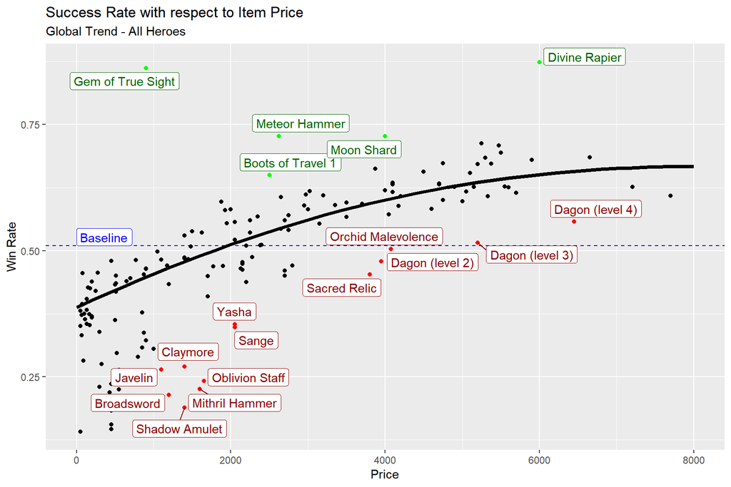

```r
high.value <- (global.matched$Delta >= SE)
low.value <- (global.matched$Price > 1000) & (global.matched$Delta <= -SE)
norm.value <- !high.value & !low.value

gplt+labs(title='Success Rate with respect to Item Price', subtitle='Global Trend - All Heroes')+
  xlab('Price')+ ylab('Win Rate')+
  geom_hline(yintercept=baseline, colour='blue', linetype=2)+
  geom_label(mapping=aes(x=0, y=baseline, label='Baseline'), vjust='bottom', hjust='left', colour='blue')+
  geom_line(data=gdata, aes(x=plot.domain, y=global.model), colour='black', size=1.5)+
  geom_point(data=global.matched[norm.value,],mapping=aes(x=Price, y=WinRate), colour='black')+
  geom_point(data=global.matched[high.value,], mapping=aes(x=Price, y=WinRate), colour='green')+
  geom_label_repel(data=global.matched[high.value,], mapping=aes(x=Price, y=WinRate, label=Item), colour='darkgreen')+
  geom_point(data=global.matched[low.value,],mapping=aes(x=Price, y=WinRate), colour='red')+
  geom_label_repel(data=global.matched[low.value,], mapping=aes(x=Price, y=WinRate, label=Item), colour='darkred')
```

#### Weighted Residuals

While there is clear evidence that price is an important factor affecting the expected success rate for an item, merely performing better than the price suggests is not sufficient evidence for the strategic superiority of a given item. When the deviations from the model are weighted by the number of games it was use in, it becomes apparent which advantages (and disadvantages) are supported by the test of time.

Given the significance of deviations from the global data, several of the labelled items on this plot will be featured in the final analysis.

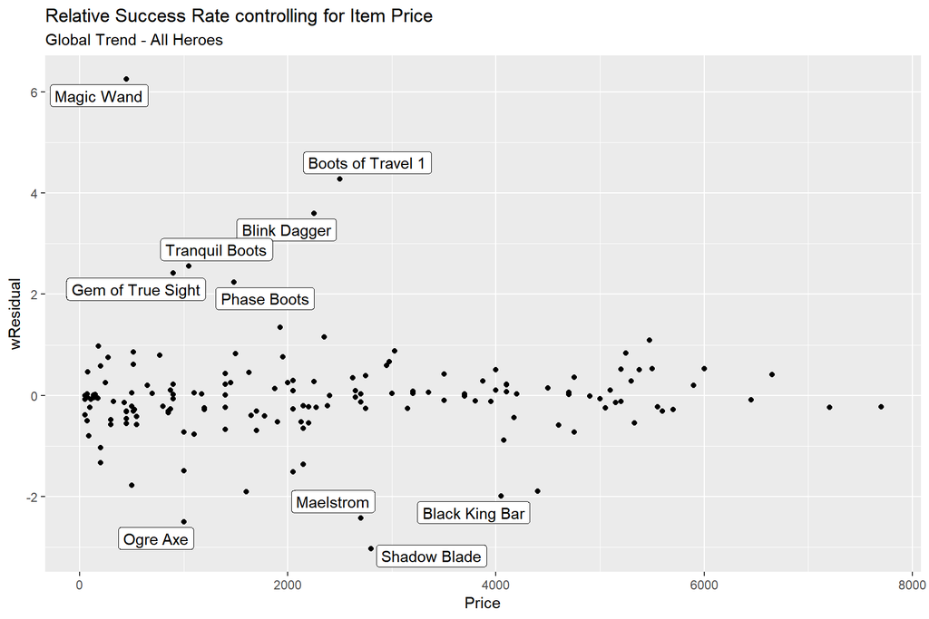

```r
tails <- as.logical(global.matched[,abs(wResidual)>1.96])

gplt+labs(title='Relative Success Rate controlling for Item Price', subtitle='Global Trend - All Heroes')+
  geom_point(aes(y=wResidual, x=Price))+
  geom_label_repel(data=global.matched[tails,], aes(y=wResidual, x=Price, label=Item))
```

### Carry Role

A ‘carry’ hero is one that is inherently weak early in the game, and becomes exponentially stronger as they collect resources. These heroes are much more likely to aquire the gold for more expensive items, and make better use of them throughout the game. In short, one would expect a carry to experience higher winrates with expensive items than the average hero. ‘Phantom Assassin’ is the hero selected to exemplify this role.

```r
url <- 'https://www.dotabuff.com/heroes/phantom-assassin/items?date=patch_7.21'
element <- '/html/body/div[1]/div[8]/div[3]/section/article/table'
carry.tbl <- html_table(html_node(x=read_html(url), xpath=element))

# put data in valid format, match item usage to prices
carry.matched <- clean(carry.tbl[,c(2,3,4)], item.prices)
```

#### Regression and Table

In order to identify items that under/over-perform, it is necessary to have some benchmark to measure them against. That is the purpose of regression modelling in this project, not to predict performance or to perfectly explain trends, just to generate a baseline level of performance that controls for the most obvious trends. While only a few notable items will be highlighted in the following plots and analysis, an interactive table of the observed and modelled data for every item is presented below.

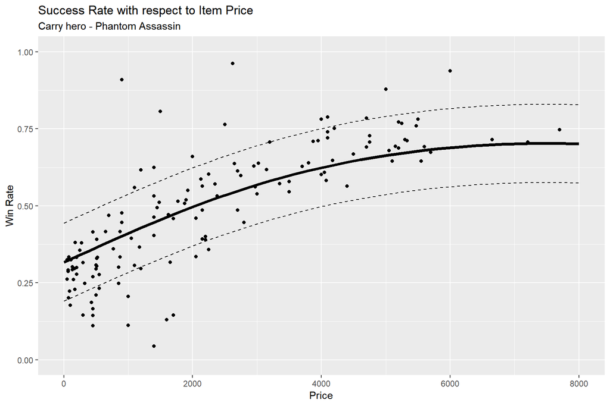

```r
# modelling and error analysis
carry.glm <- glm(data=carry.matched, family=binomial(link='logit'),
                  formula=WinRate~Price+I(Price^2), weights=MatchesPlayed)
carry.matched$Model <- round(predict.glm(carry.glm, type='response', newdata=data.frame(Price=carry.matched$Price)), 4)
carry.matched$Delta <- carry.matched[, WinRate-Model]
carry.matched$wResidual <- carry.matched[,scale(Delta*MatchesPlayed)]

# additional information for visualization
cplt <- ggplot(data=carry.matched)
carry.model <- predict.glm(carry.glm, type='response', newdata=data.frame(Price=plot.domain))
cdata <- data.frame(plot.domain, carry.model)
baseline <- carry.matched[,sum(MatchesPlayed*WinRate) / sum(MatchesPlayed)]
SE <- sd(carry.matched$Delta)

# construct the visual
cplt+labs(title='Success Rate with respect to Item Price', subtitle='Carry hero - Phantom Assassin')+
  xlab('Price')+ ylab('Win Rate')+
  scale_y_continuous(limits=c(0,1))+
  geom_line(data=cdata, aes(x=plot.domain, y=carry.model+SE), colour='black', linetype=2)+
  geom_line(data=cdata, aes(x=plot.domain, y=carry.model-SE), colour='black', linetype=2)+
  geom_line(data=cdata, aes(x=plot.domain, y=carry.model), colour='black', size=1.5)+
  geom_point(mapping=aes(x=Price, y=WinRate), colour='black')
```

```r
# generate interactive table
datatable(filter='top', rownames=FALSE, escape=TRUE, options=list(order=list(5,'desc')),
          data=carry.matched[,.(Item,Price,UseRate=percent(UseRate), WinRate=percent(WinRate),
                                 Model=percent(Model), Delta=percent(Delta), `Weighted Residual`=round(wResidual,2))])
```

| Item | Price | UseRate | WinRate | Model | Delta | Weighted Residual |
| --- | --- | --- | --- | --- | --- | --- |
| Abyssal Blade | 6650 | 21.1% | 71.5% | 69.8% | 1.7% | 0.64 |
| Aeon Disk | 3350 | 0.2% | 57.2% | 59.0% | -1.8% | -0.01 |
| Aether Lens | 2350 | 0.0% | 57.0% | 52.3% | 4.7% | 0 |
| Aghanim's Scepter | 4200 | 0.0% | 75.2% | 63.3% | 11.9% | 0 |
| Arcane Boots | 1400 | 0.0% | 40.4% | 44.6% | -4.2% | 0 |
| Armlet of Mordiggian | 2380 | 0.2% | 53.1% | 52.6% | 0.6% | 0 |
| Assault Cuirass | 5250 | 1.4% | 76.8% | 67.1% | 9.7% | 0.24 |
| Band of Elvenskin | 450 | 0.1% | 14.3% | 36.0% | -21.6% | -0.03 |
| Battle Fury | 4400 | 39.3% | 56.3% | 64.2% | -7.8% | -5.53 |
| Belt of Strength | 450 | 1.0% | 16.6% | 36.0% | -19.4% | -0.35 |

[output cut: 129 more lines]

#### Visual Trend

Now that there is a model for price-adjusted average performance, it is worth noting which items represent significant departures and identifying the other possible factors at play. Ultimately the goal is not just to identify outliers, but to extract strategic advice that is justified by those peculiarities in the data.

Comparing the carry model to the global average trend, price has a more exaggerated impact on expected win rates. This would suggest that for carries, there can be less focus on inexpensive (cost-efficient) items, and players should prioritize items that provide the most total benefit. This fits with the strategic role of the carry, in that they allocate more time to aquiring gold while teammates run interference, and are later relied upon to have the greatest strength for objective-taking. A simple conclusion is that a carry should plan to buy the most powerful items, and expect to spend a proportionate amount of time on gold aquisition.

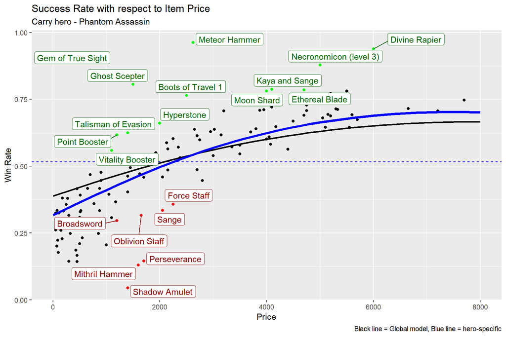

```r
high.value <- (carry.matched$Delta >= SE)
low.value <- (carry.matched$Price > 1000) & (carry.matched$Delta <= -SE)
norm.value <- !high.value & !low.value

cplt+labs(title='Success Rate with respect to Item Price', subtitle='Carry hero - Phantom Assassin',
          caption='Black line = Global model, Blue line = hero-specific')+
  xlab('Price')+ ylab('Win Rate')+
  geom_hline(yintercept=baseline, colour='blue', linetype=2)+
  geom_point(data=carry.matched[norm.value,],mapping=aes(x=Price, y=WinRate), colour='black')+
  geom_line(data=gdata, aes(x=plot.domain, y=global.model), colour='black', size=1)+
  geom_line(data=cdata, aes(x=plot.domain, y=carry.model), colour='blue', size=1.5)+
  geom_point(data=carry.matched[high.value,], mapping=aes(x=Price, y=WinRate), colour='green')+
  geom_label_repel(data=carry.matched[high.value,], mapping=aes(x=Price, y=WinRate, label=Item), colour='darkgreen')+
  geom_point(data=carry.matched[low.value,],mapping=aes(x=Price, y=WinRate), colour='red')+
  geom_label_repel(data=carry.matched[low.value,], mapping=aes(x=Price, y=WinRate, label=Item), colour='darkred')
```

#### Weighted Residuals

While there is clear evidence that price is an important factor affecting the expected success rate for an item, merely performing better than the price suggests is not sufficient evidence for the strategic superiority of a given item. When the deviations from the model are weighted by the number of games it was use in, it becomes apparent which advantages (and disadvantages) are supported by the test of time.

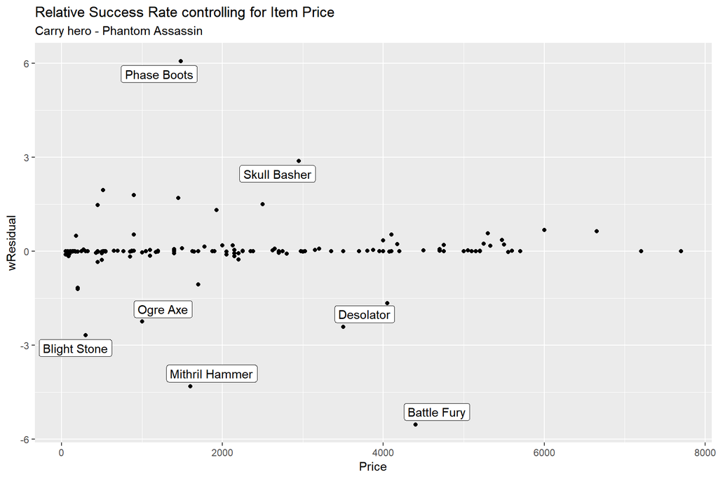

```r
tails <- as.logical(carry.matched[,abs(wResidual)>1.96])

cplt+labs(title='Relative Success Rate controlling for Item Price', subtitle='Carry hero - Phantom Assassin')+
  geom_point(aes(y=wResidual, x=Price))+
  geom_label_repel(data=carry.matched[tails,], aes(y=wResidual, x=Price, label=Item))
```

### Support Role

‘Support’ heroes are those that have strong abilities to inhibit enemies and bolster teammates right from the early stages of the game. The tradeoff is that their capability doesn’t increase by the same magnitude as other heroes, making them relatively vulnerable targets later in the game. ‘Crystal Maiden’ is the hero selected to exemplify this role.

```r
url <- 'https://www.dotabuff.com/heroes/crystal-maiden/items?date=patch_7.21'
element <- '/html/body/div[1]/div[8]/div[3]/section/article/table'
support.tbl <- html_table(html_node(x=read_html(url), xpath=element))

# put data in valid format, match item usage to prices
support.matched <- clean(support.tbl[,c(2,3,4)], item.prices)
```

#### Regression and Table

In order to identify items that under/over-perform, it is necessary to have some benchmark to measure them against. That is the purpose of regression modelling in this project, not to predict performance or to perfectly explain trends, just to generate a baseline level of performance that controls for the most obvious trends. While only a few notable items will be highlighted in the following plots and analysis, an interactive table of the observed and modelled data for every item is presented below.

[figure not shown]

```r
# modelling and error analysis
support.glm <- glm(data=support.matched, family=binomial(link='logit'),
                  formula=WinRate~Price+I(Price^2), weights=MatchesPlayed)
support.matched$Model <- round(predict.glm(support.glm, type='response', newdata=data.frame(Price=support.matched$Price)), 4)
support.matched$Delta <- support.matched[, WinRate-Model]
support.matched$wResidual <- support.matched[,scale(Delta*MatchesPlayed)]

# additional information for visualization
splt <- ggplot(data=support.matched)
support.model <- predict.glm(support.glm, type='response', newdata=data.frame(Price=plot.domain))
sdata <- data.frame(plot.domain, support.model)
baseline <- support.matched[,sum(MatchesPlayed*WinRate) / sum(MatchesPlayed)]
SE <- sd(support.matched$Delta)

# construct the visual
cplt+labs(title='Success Rate with respect to Item Price', subtitle='Support hero - Crystal Maiden')+
  xlab('Price')+ ylab('Win Rate')+
  scale_y_continuous(limits=c(0,1))+
  geom_line(data=cdata, aes(x=plot.domain, y=support.model+SE), colour='black', linetype=2)+
  geom_line(data=cdata, aes(x=plot.domain, y=support.model-SE), colour='black', linetype=2)+
  geom_line(data=cdata, aes(x=plot.domain, y=support.model), colour='black', size=1.5)+
  geom_point(mapping=aes(x=Price, y=WinRate), colour='black')
```

```r
# generate interactive table
datatable(filter='top', rownames=FALSE, escape=TRUE, options=list(order=list(5,'desc')),
          data=support.matched[,.(Item,Price,UseRate=percent(UseRate), WinRate=percent(WinRate),
                                 Model=percent(Model), Delta=percent(Delta), `Weighted Residual`=round(wResidual,2))])
```

| Item | Price | UseRate | WinRate | Model | Delta | Weighted Residual |
| --- | --- | --- | --- | --- | --- | --- |
| Abyssal Blade | 6650 | 0.0% | 57.3% | 62.1% | -4.8% | 0 |
| Aeon Disk | 3350 | 3.3% | 63.3% | 63.6% | -0.3% | -0.04 |
| Aether Lens | 2350 | 4.5% | 62.5% | 60.5% | 2.0% | 0.4 |
| Aghanim's Scepter | 4200 | 15.1% | 66.7% | 64.9% | 1.7% | 1.14 |
| Arcane Boots | 1400 | 1.8% | 53.3% | 55.9% | -2.6% | -0.2 |
| Armlet of Mordiggian | 2380 | 0.0% | 64.6% | 60.6% | 3.9% | 0 |
| Assault Cuirass | 5250 | 0.1% | 67.6% | 64.9% | 2.6% | 0.01 |
| Band of Elvenskin | 450 | 0.1% | 46.0% | 49.5% | -3.5% | -0.01 |
| Belt of Strength | 450 | 0.1% | 38.0% | 49.5% | -11.5% | -0.03 |
| Black King Bar | 4050 | 17.0% | 63.3% | 64.8% | -1.5% | -1.13 |

[output cut: 146 more lines]

#### Visual Trend

Now that there is a model for price-adjusted average performance, it is worth noting which items represent significant departures and identifying the other possible factors at play. Ultimately the goal is not just to identify outliers, but to extract strategic advice that is justified by those peculiarities in the data.

In stark contrast to the carry hero, this plot shows a strong preference for moderate and low-cost items, and more severe diminishing returns from expensive items. It may not be that more expensive items aren’t useful to supports, so much as they represent a high opportunity cost relative to other ways of spending time and resources. Because most of a support’s time *should* be spent enabling their team as the others collect gold, they generally get less to work with for themselves. In this context, it seems advisable to prioritize less-expensive and more cost-efficient items.

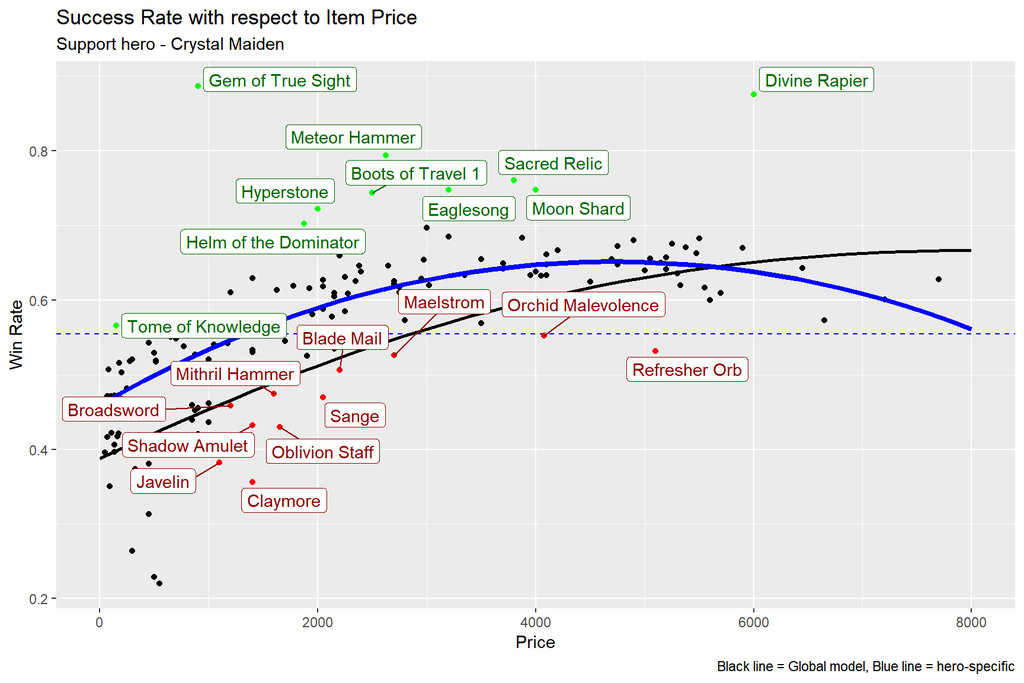

```r
high.value <- (support.matched$Delta >= SE)
low.value <- (support.matched$Price > 1000) & (support.matched$Delta <= -SE)
norm.value <- !high.value & !low.value

cplt+labs(title='Success Rate with respect to Item Price', subtitle='Support hero - Crystal Maiden',
          caption='Black line = Global model, Blue line = hero-specific')+
  xlab('Price')+ ylab('Win Rate')+
  geom_hline(yintercept=baseline, colour='blue', linetype=2)+
  geom_point(data=support.matched[norm.value,],mapping=aes(x=Price, y=WinRate), colour='black')+
  geom_line(data=gdata, aes(x=plot.domain, y=global.model), colour='black', size=1)+
  geom_line(data=sdata, aes(x=plot.domain, y=support.model), colour='blue', size=1.5)+
  geom_point(data=support.matched[high.value,], mapping=aes(x=Price, y=WinRate), colour='green')+
  geom_label_repel(data=support.matched[high.value,], mapping=aes(x=Price, y=WinRate, label=Item), colour='darkgreen')+
  geom_point(data=support.matched[low.value,],mapping=aes(x=Price, y=WinRate), colour='red')+
  geom_label_repel(data=support.matched[low.value,], mapping=aes(x=Price, y=WinRate, label=Item), colour='darkred')
```

#### Weighted Residuals

While there is clear evidence that price is an important factor affecting the expected success rate for an item, merely performing better than the price suggests is not sufficient evidence for the strategic superiority of a given item. When the deviations from the model are weighted by the number of games it was use in, it becomes apparent which advantages (and disadvantages) are supported by the test of time.

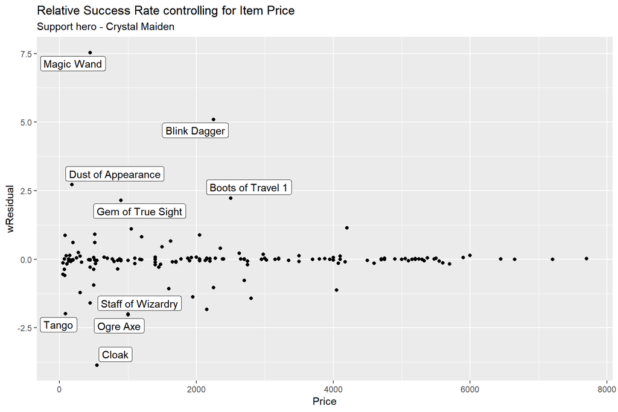

```r
tails <- as.logical(support.matched[,abs(wResidual)>1.96])

splt+labs(title='Relative Success Rate controlling for Item Price', subtitle='Support hero - Crystal Maiden')+
  geom_point(aes(y=wResidual, x=Price))+
  geom_label_repel(data=support.matched[tails,], aes(y=wResidual, x=Price, label=Item))
```

## Results

It is only feasible to examine a very select subset of the data that has been processed in any detail. A few of the most extreme data points from the above figures have been chosen for closer inspection in hopes of gaining insight into some of the best and worst item choices.

**Positive Outliers**

Magic Wand’s winrate is only slightly higher than expected for its low price, but the fact that it has demonstrated that advantage across an overwhelming number of games (as evidenced by the weighted residual) is a very strong endorsement of the strategic value it can offer. This recommendation likely remains valid for a wide variety of heroes, team strategies, and player skill levels. Given the two specific heroes sampled, there is a slightly stronger endorsement for support heroes to always buy Magic Wand (ocnsistent with the preference for less expensive items), but there was still some evidence of better-than-average value for the carry example.

**Negative Outliers**

Black King Bar is an item that grants temporary invincibility to certain types of damage, which should be quite advantageous in any scenario and it is indeed one of the most popular items across all heroes. Yet it has one of the more negative weighted residuals in the global data, and still slightly underperforms its price for both the sampled heroes. It would seem that despite its obvious utility, only a minority of heroes/players can reap benefits that offset the substantial cost of the item.

Shadow Blade gets the dubious honour of having the most negative weighted residual in the global data; it does underperform its price to a moderate degree, but it seems to be more popular than is warranted. It is an item that provides temporary invisibility among other benefits, which certainly has a strategic appeal, especially to those that don’t have much understanding of the game. The hard truth for the many players favouring the item is that Dota provides (relatively inexpensive) items that specifically neutralize or reverse the advantage of invisibility, and skilled players make routine use of those tools. It would be an over-simplification to say that the item is universally useless, but it seems safe to say it is not as valuable as many players appear to believe.

A final consideration goes to the Ogre Axe, which appears to be often used but underperforms its low price for each sample considered. This item is an example of the item-building mechanic, as a component that is generally bought and used to build one of several more expensive items. A plausible explanation is that for the majority of cases, those that had an Ogre Axe (recorded at the end of the game) intended to build something more impactful, but due to lack of resources and lack of benefit from other items while saving up, the game ended as a loss for them. This would seem consistent with the generally low winrates for low-cost items. There is no way to guess from this data what they were planning to buy, and thus which item to attribute the losing (or miraculously winning) strategy to. So while numerically remarkable, there is not really an actionable recommendation to be gained from this data point.